# First Model

Hakan Egeli

Soumyendu Sarkar

April 17, 2018

## Project Setup

We chose to go with the ProjectTemplate package and structured our project accordingly. With this setup, our data gets automatically loaded from the data directory and using the munge feature we also automatically build a **training set** and a **test set** by dividing the original dataset using a 80/20 ratio. To make sure that both the training and the test sets have similar distributions, we used the `createDataPartition()` function and split the data over the **CreditLimit** variable.

We also set the `seed` to a fixed number so that we can produce the same sequence of random numbers between runs and our results are not effected by the changes in the datasets.

## Naive Model

Instead of using a mean value for the credit limit for our Naive model, we chose Last Year's Sales (SalesLastYr) independent variable to predict Credit Limits. Our goal is to see whether we can formulate the Credit Limit with a simple equation as the following and whether this realtionship is good enough to get acceptable predictions for Credit Limits:

$$Credit Limit = w*Previous Years Sales+b$$

```r
model <- lm(formula = CreditLimit ~ SalesLastYr, data = dataset_train)
```

```
##
## Call:
## lm(formula = CreditLimit ~ SalesLastYr, data = dataset_train)
##
## Residuals:
##     Min      1Q  Median      3Q     Max
## -4288.7 -1769.8    64.4  2151.8  2268.7
##
## Coefficients:
##              Estimate Std. Error t value Pr(>|t|)
## (Intercept) 2.731e+03  5.525e+01  49.432  < 2e-16 ***
## SalesLastYr 1.250e-02  2.329e-03   5.367 9.37e-08 ***
## ---
## Signif. codes:  0 '***' 0.001 '**' 0.01 '*' 0.05 '.' 0.1 ' ' 1
##
## Residual standard error: 1829 on 1385 degrees of freedom
## Multiple R-squared:  0.02037,    Adjusted R-squared:  0.01967
## F-statistic:  28.8 on 1 and 1385 DF,  p-value: 9.374e-08
```

The **summary** results of this model trained using the **training set** shows that both the intercept (b) and the coefficient (w) are significant (P values are much less than 0.05). This might be a good start but how good of a fit is this model to our data?

R-squared paramater indicates the the fitness of a model and we want this value to be closer to 1, aka we want the ratio of the sum of the square of the residuals ($SS_r$) over the sum of the square of the averages ($SS_t$) to be small so that $R^2$ becomes larger.

$$R^2 = 1 - SS_r/SS_t$$

The value 0.020374 for the $R^2$ seemed low which is indicating that the model is not a good fit. And at this time we are not concerned with the Adjusted $R^2$ since we have only one independent variable in our model.

The three perfomance metrics, $R^2$, Adjusted $R^2$ and the RMSE, for the **training set** are:

```
## R Squared:  0.02037401
```

```
## R Squared (Adjusted):  0.0196667
```

```
## Root Mean Square Error:  1827.308
```

And same metrics for the **test set** are:

```
## R Squared:  0.01875098
```

```
## R Squared (Adjusted):  0.0158902
```

```
## Root Mean Square Error:  1828.77
```

The $R^2$ values are very close to eachother for the test set than the training set but in both cases these values still indicate not a good fit. The RSME values for both the raining and the test sets seems to be close to each other as well and we hope to see these numbers (RSME) go lower and the $R^2$ values go higher as we build better models.

## Interpretation of the Model and the Data

We have performed a preliminary data analysis and we began our examination of the data with the **Sales** numbers for the last calender year. We looked at the min, max, std dev and the quintiles to understand the spread of the data as well as to be able to do a comparison between the training and the test sets.

#### Training Set Summary

```
##    Min. 1st Qu.  Median    Mean 3rd Qu.    Max.
##   -2227    1830    4972   10878   11633  428636
```

```
## Std Dev. 21085.92
```

#### Test Set Summary

```
##    Min. 1st Qu.  Median    Mean 3rd Qu.    Max.
##       0    2319    5036   10723   11986  115704
```

```
## Std Dev. 15646.71
```

Both in the training set and the test set these numbers seemed to be close to each other and we do notice that the Sales numbers are clustred more towards the left of the scale. To visulaize this better, we have created a histogram of the sales numbers for the traning set and the test set so that we can do a side by side analysis.

#### Comparison of Distribution of Sales Between the Training Set and the Test Set

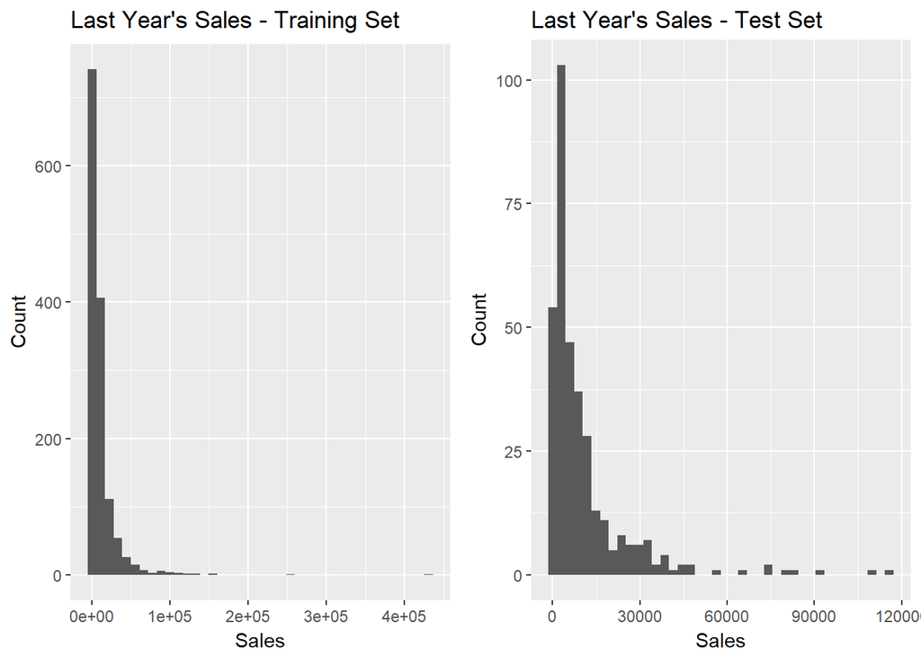

Upon visual inspection of the **Sales** data between the training and the test sets, we do see that they are distributed similarly.

We also wanted to see how the distrubution of Last Year's Sales looked like compared to the distribution of Credit Limits for the same data points.

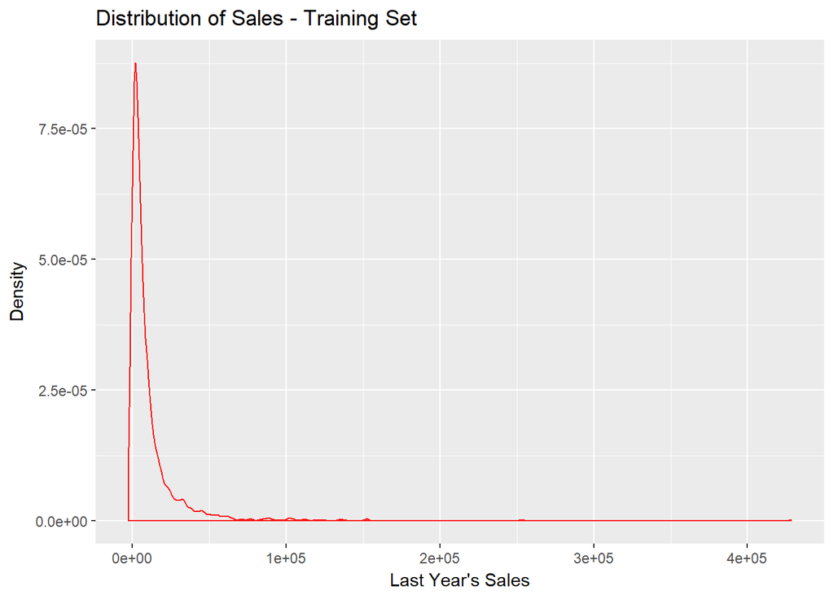

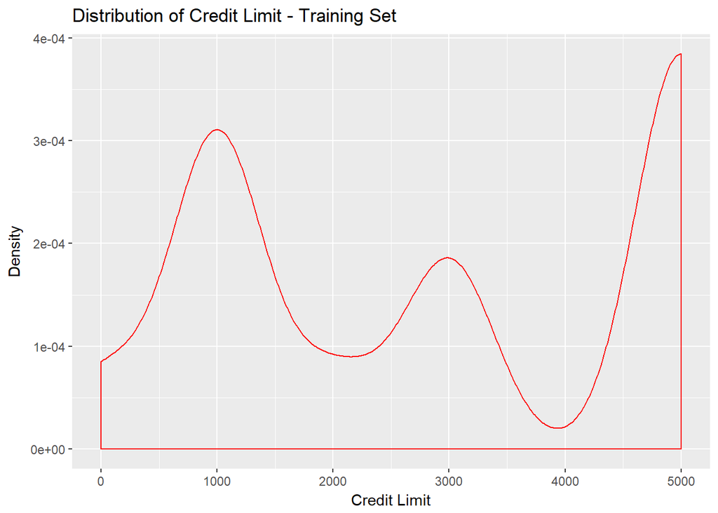

## Performance of the Model

To better understand the correlation between these two variables and how our model repsresents this data, we have plotted the **Credit Limit vs. Last Year's Sales** and also plotted a line representing our model.

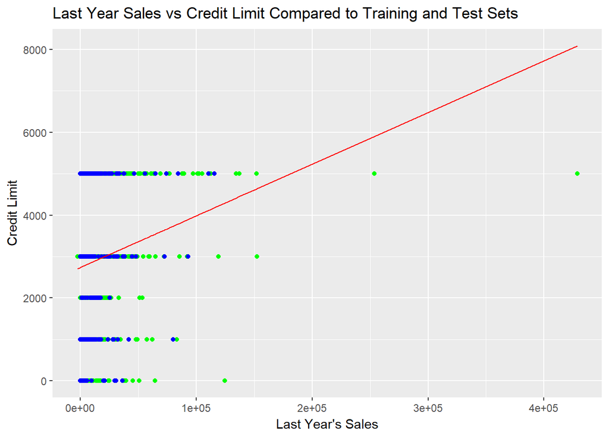

From the plot of the data Credit Limit vs the Last Year's Sales, we do see that the two variables are not correlated and that is why our linear model is not performing well.

It is possible that the Credit Limit cannot be explained by one varaible and a linear relationship might still exist using other independent variables. It is also possible that the relationships are non-linear and we might have to try non-linear models to explain the data.

## Next Step

We will try to improve our linear model by examining all other variables that we have in our dataset and use a **Backward Elimitaion** to find out the most significant variables which might help us to build a better model. As we add more variables to describe our model we will also utilize the $Adjusted R^2$ predictor to account for the impact of the added variables to the $R^2$ value.

Future steps will also include adding non-linear terms to the model or building other classification models such as one which uses a **Decision Tree** or take advantage of ensemble learning by building a model using **Random Forest**.

We will evaluate the performance of these models against our performance metrics which we have established in the FPS document.